# Streaming Services - Stock Price Analysis

## Introduction

To this day, it has been found that the television audience has been increasingly fragmenting. The main television channels share increasingly lower quotas. Among other reasons, there is the rising of different digital platforms with many original content: movies, series and documentaries that has made the viewers prefer to choose what to watch, when to watch it and where.

The options available to date are gaining more and more followers every day. The huge offer is seeking to capture the attention of any type of audience. Anyone can hire a service specialized in this type of content to enjoy it no matter when or where. In addition, the additional functions included in most streaming platforms give rise to a flexibility that ends up convincing many.

The enormous popularity of many of their own productions has become a value that they usually highlight: Game of Thrones and Stranger Things are good examples of this. Although not the only ones, since many of these options enrich their catalog with titles from other producers and even from their rivals.

## Objetive

We are interested in knowing the performance of the 4 top streaming services in terms of views of their top shows and if them had impact within their stock prices.

## Data

```r
library(quantmod)
library(dplyr)
library(tidyverse)
library(maps)
library(mxmaps)
library(gtrendsR)
```

We will start by getting the stock prices historical data of Disney, Amazon, Netflix and AT&T(HBO) from the past 10+ years using the quantmod library.

```r
streaming <- c('DIS', 'AMZN', 'NFLX', 'T')
getSymbols(streaming)
```

```
[1] "DIS"  "AMZN" "NFLX" "T"
```

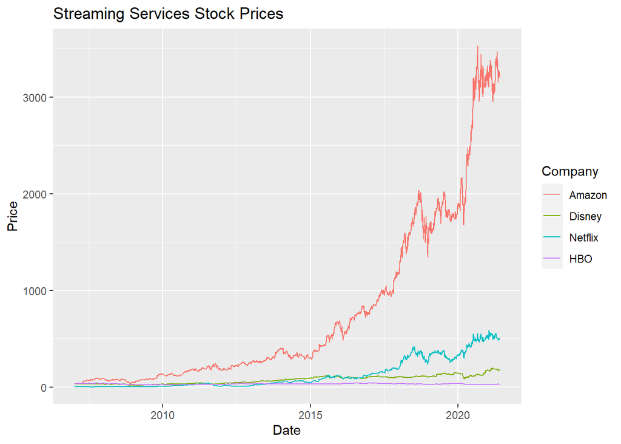

```r
stocks <- data.frame('Amazon' = AMZN$AMZN.Close,
                     'Netflix' = NFLX$NFLX.Close,
                     'Disney'=DIS$DIS.Close,
                     'HBO' = T$T.Close,
                     'Date' = as.Date(row.names(as.data.frame(NFLX))))

graph <- stocks %>%
  gather(value = 'value', key = 'stock', -Date)

graph %>% ggplot() +
  geom_line(aes(x = Date,
                y= value,
                color = stock)) +
  scale_color_discrete(name = 'Company',
                       labels = c('Amazon', 'Disney', 'Netflix', 'HBO')) +
  labs(title = 'Streaming Services Stock Prices',
       y = 'Price')
```

Next, we will use gtrendsR to gather data about the popularity of google search terms over time to get to know the impact each show has had among the population and its released date. A visual of the data can help us understand easily the impact magnitud of each show.

```r
hits <- gtrends(keyword=c('game of thrones',
                          'the mandalorian',
                          'stranger things',
                          'the marvelous mrs. maisel'))
trend <- hits$interest_over_time
trend <- trend %>% mutate(hits = as.numeric(hits))
```

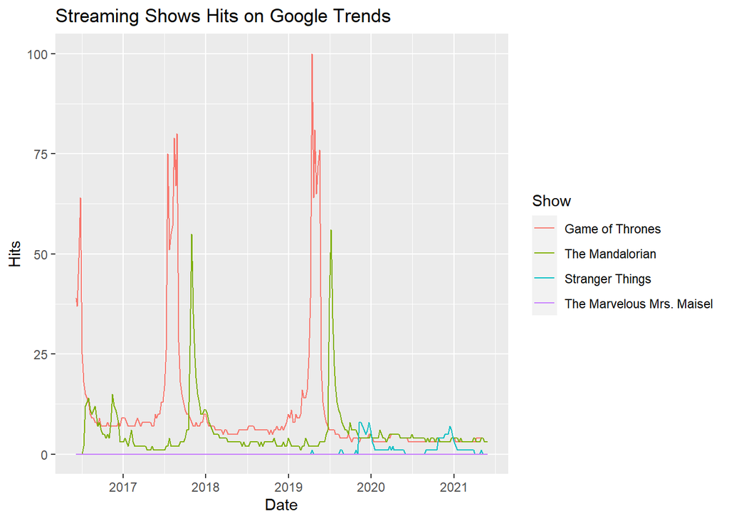

```r
trend <- trend %>%
  replace_na(list(hits = 0))

trend %>%
  ggplot() + geom_line(aes(date,
                           hits,
                           color = keyword)) +
  scale_color_discrete(name = 'Show',
                       labels = c('Game of Thrones',
                                  'The Mandalorian',
                                  'Stranger Things',
                                  'The Marvelous Mrs. Maisel' )) +
  labs(title = 'Streaming Shows Hits on Google Trends',
       y = 'Hits',
       x = 'Date')
```

## Us Trends Geographical Distribution

An interesting google trends factor to get to know the viewers market is to get a sight of the fandom distribution, where are the show more popular? This way companies can know where to focus their efforts to increase sells revenue or where do they have to invest in advertising. This type of insights may help companies get a better understanding of who is watching their shows.

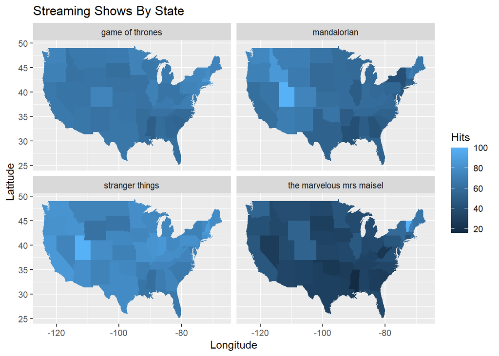

```r
us_trends <-  gtrends(keyword=c('mandalorian', 'stranger things', 'game of thrones', 'the marvelous mrs maisel'), geo = 'US')

us_states <- us_trends$interest_by_region
us_states <- us_states %>%
  mutate(location = tolower(location))

us_map <- map_data('state')

us_states %>% ggplot(aes(map_id = location)) +
  geom_map(aes(fill = hits),
           map = us_map) +
  expand_limits(x = us_map$long,
                y = us_map$lat) +
  facet_wrap(~ keyword,
             nrow = 2) +
  labs(title = 'Streaming Shows By State',
       y = 'Latitude',
       x = 'Longitude') +
  scale_fill_continuous(name = 'Hits')
```